# Linear models

Marta Coronado

2022-05-24

## Read data

From **Appendix 1** we take the information on `repeat`, `location`, `LT50`, `Latitude`, `Longitude`, and `Strain` (Appendix 1, and Mortality data).

```r
info1 <- read.table("info1_revised.tab", header = T, sep = "\t", stringsAsFactors = T)
head(info1)
```

From **Appendix 2** we take the information on pollutants of each location, the distance to the closest city of >50k inhabitants, and the urban category.

```r
info2 <- read.table("info2_revised.tab", header = T, sep = "\t", stringsAsFactors = T)
info2
```

```r
#data <- merge(info1, info2, by="Strain")
#write.table(data, "dataLM.tab", col.names = T, row.names = F, sep = "\t", quote = F)
data <- read.table("dataLM.tab", header = T, sep = "\t", stringsAsFactors = T)
head(data)
```

```
##   Strain Repeat Location  LT50 Latitude Longitude     PM10    PM2.5  Arsenic
## 1 AT_MUT   MA18       MA 61.60    48.38     15.56 20.95936 15.77764 0.653863
## 2 AT_MUT   MA63       MA 46.04    48.38     15.56 20.95936 15.77764 0.653863
## 3 AT_MUT   MA23       MA 49.17    48.38     15.56 20.95936 15.77764 0.653863
## 4 AT_MUT  MA131       MA 39.52    48.38     15.56 20.95936 15.77764 0.653863
## 5 AT_MUT  MA127       MA 48.35    48.38     15.56 20.95936 15.77764 0.653863
## 6 AT_MUT   MA65       MA 46.34    48.38     15.56 20.95936 15.77764 0.653863
##   Cadmium     Lead Copper AreaClassification
## 1    0.13 0.004831   18.6         Semi-urban
## 2    0.13 0.004831   18.6         Semi-urban
## 3    0.13 0.004831   18.6         Semi-urban
## 4    0.13 0.004831   18.6         Semi-urban
## 5    0.13 0.004831   18.6         Semi-urban
## 6    0.13 0.004831   18.6         Semi-urban
```

```r
data$AreaClassification <- factor(data$AreaClassification, levels=c("Urban", "Semi-urban", "Rural"))
```

Analysis figure 1C.

```r
data$par45 <- ""
data[data$Location=="MA",]$par45 <- "NE"
data[data$Location=="MUN",]$par45 <- "NE"
data[data$Location=="DEN",]$par45 <- "NE"
data[data$Location=="SW",]$par45 <- "NE"
data[data$Location=="FIN",]$par45 <- "NE"
data[data$Location=="BZ",]$par45 <- "SE"
data[data$Location=="GIM",]$par45 <- "SE"
data[data$Location=="TF",]$par45 <- "SE"
data[data$Location=="TOM",]$par45 <- "SE"
data[data$Location=="CAS",]$par45 <- "SE"
data[data$Location=="RE",]$par45 <- "SE"
data[data$Location=="GUA",]$par45 <- "SE"
wilcox.test(data[data$par45=="NE" & data$Location!="MA",]$LT50,data[data$par45=="SE" & data$Location!="RE"  & data$Location!="CAS",]$LT50, alternative = "greater")
```

```
##
##  Wilcoxon rank sum exact test
##
## data:  data[data$par45 == "NE" & data$Location != "MA", ]$LT50 and data[data$par45 == "SE" & data$Location != "RE" & data$Location != "CAS", ]$LT50
## W = 818, p-value = 0.00529
## alternative hypothesis: true location shift is greater than 0
```

```r
wilcox.test(data[data$par45=="NE",]$LT50,data[data$par45=="SE",]$LT50,alternative = "greater")
```

```
##
##  Wilcoxon rank sum test with continuity correction
##
## data:  data[data$par45 == "NE", ]$LT50 and data[data$par45 == "SE", ]$LT50
## W = 1362, p-value = 0.0189
## alternative hypothesis: true location shift is greater than 0
```

## Linear models

LM with all variables:

```r
lmAll = lm(LT50  ~ Longitude + Latitude +
           Copper + PM10 + PM2.5 +
           Arsenic + Cadmium + Lead +
           AreaClassification,
         data = data)
summary(lmAll)
```

```
##
## Call:
## lm(formula = LT50 ~ Longitude + Latitude + Copper + PM10 + PM2.5 +
##     Arsenic + Cadmium + Lead + AreaClassification, data = data)
##
## Residuals:
##     Min      1Q  Median      3Q     Max
## -27.394  -8.363  -1.974   9.140  29.469
##
## Coefficients:
##                              Estimate Std. Error t value Pr(>|t|)
## (Intercept)                  -40.4626    94.0810  -0.430  0.66832
## Longitude                     -1.3184     2.3350  -0.565  0.57396
## Latitude                       1.7550     2.6526   0.662  0.51015
## Copper                         0.7590     0.3987   1.904  0.06061 .
## PM10                           0.2488     1.8956   0.131  0.89593
## PM2.5                          0.6793     0.6526   1.041  0.30112
## Arsenic                        8.1615    26.5353   0.308  0.75923
## Cadmium                      -40.4943   174.0301  -0.233  0.81662
## Lead                           0.4308     4.3394   0.099  0.92117
## AreaClassificationSemi-urban  -5.0665    23.1506  -0.219  0.82734
## AreaClassificationRural      -16.8090     6.2736  -2.679  0.00899 **
## ---
## Signif. codes:  0 '***' 0.001 '**' 0.01 '*' 0.05 '.' 0.1 ' ' 1
##
## Residual standard error: 12.54 on 78 degrees of freedom
##   (8 observations deleted due to missingness)
## Multiple R-squared:  0.1921, Adjusted R-squared:  0.08853
## F-statistic: 1.855 on 10 and 78 DF,  p-value: 0.06465
```

### Backward stepwise regression

We want the model with only relevant variables. We can use `dropterm()` to remove variables that are not informative. The model should be explaining the same amount of variance but only with the relevant variables.

The procedure is to remove variables 1 by 1, starting from the least significant,

```r
dropterm(lmAll, test = "F")
```

```
## Single term deletions
##
## Model:
## LT50 ~ Longitude + Latitude + Copper + PM10 + PM2.5 + Arsenic +
##     Cadmium + Lead + AreaClassification
##                    Df Sum of Sq   RSS    AIC F Value   Pr(F)
## <none>                          12259 460.36
## Longitude           1     50.10 12309 458.72  0.3188 0.57396
## Latitude            1     68.80 12328 458.86  0.4378 0.51015
## Copper              1    569.72 12828 462.40  3.6250 0.06061 .
## PM10                1      2.71 12262 458.38  0.0172 0.89593
## PM2.5               1    170.30 12429 459.59  1.0835 0.30112
## Arsenic             1     14.87 12274 458.47  0.0946 0.75923
## Cadmium             1      8.51 12267 458.42  0.0541 0.81662
## Lead                1      1.55 12260 458.37  0.0099 0.92117
## AreaClassification  2   1149.60 13408 464.34  3.6573 0.03032 *
## ---
## Signif. codes:  0 '***' 0.001 '**' 0.01 '*' 0.05 '.' 0.1 ' ' 1
```

We first remove `Lead`, as it is the least significant variable.

```r
lm2 = lm(LT50  ~ Longitude + Latitude +
           Copper + PM10 + PM2.5 +
           Arsenic + Cadmium +
           AreaClassification,
         data = data)
summary(lm2)
```

```
##
## Call:
## lm(formula = LT50 ~ Longitude + Latitude + Copper + PM10 + PM2.5 +
##     Arsenic + Cadmium + AreaClassification, data = data)
##
## Residuals:
##     Min      1Q  Median      3Q     Max
## -27.349  -8.183  -1.929   9.272  29.453
##
## Coefficients:
##                              Estimate Std. Error t value Pr(>|t|)
## (Intercept)                  -32.1375    42.3846  -0.758  0.45057
## Longitude                     -1.1049     0.9054  -1.220  0.22593
## Latitude                       1.5068     0.8783   1.716  0.09015 .
## Copper                         0.7553     0.3944   1.915  0.05910 .
## PM10                           0.4238     0.6925   0.612  0.54236
## PM2.5                          0.6383     0.5026   1.270  0.20777
## Arsenic                       10.5884    10.2554   1.032  0.30500
## Cadmium                      -56.6349    61.6881  -0.918  0.36137
## AreaClassificationSemi-urban  -7.1051    10.6237  -0.669  0.50558
## AreaClassificationRural      -16.8003     6.2335  -2.695  0.00859 **
## ---
## Signif. codes:  0 '***' 0.001 '**' 0.01 '*' 0.05 '.' 0.1 ' ' 1
##
## Residual standard error: 12.46 on 79 degrees of freedom
##   (8 observations deleted due to missingness)
## Multiple R-squared:  0.192,  Adjusted R-squared:  0.09995
## F-statistic: 2.086 on 9 and 79 DF,  p-value: 0.04054
```

```r
dropterm(lm2, test = "F")
```

```
## Single term deletions
##
## Model:
## LT50 ~ Longitude + Latitude + Copper + PM10 + PM2.5 + Arsenic +
##     Cadmium + AreaClassification
##                    Df Sum of Sq   RSS    AIC F Value   Pr(F)
## <none>                          12260 458.37
## Longitude           1    231.16 12492 458.03  1.4895 0.22593
## Latitude            1    456.80 12717 459.62  2.9434 0.09015 .
## Copper              1    569.17 12830 460.41  3.6675 0.05910 .
## PM10                1     58.11 12318 456.79  0.3744 0.54236
## PM2.5               1    250.36 12511 458.17  1.6132 0.20777
## Arsenic             1    165.44 12426 457.56  1.0660 0.30500
## Cadmium             1    130.81 12391 457.31  0.8429 0.36137
## AreaClassification  2   1217.85 13478 462.80  3.9236 0.02374 *
## ---
## Signif. codes:  0 '***' 0.001 '**' 0.01 '*' 0.05 '.' 0.1 ' ' 1
```

We remove `PM10`.

```r
lm3 = lm(LT50  ~ Longitude + Latitude +
           Copper + PM2.5 +
           Arsenic + Cadmium +
           AreaClassification,
         data = data)
summary(lm3)
```

```
##
## Call:
## lm(formula = LT50 ~ Longitude + Latitude + Copper + PM2.5 + Arsenic +
##     Cadmium + AreaClassification, data = data)
##
## Residuals:
##     Min      1Q  Median      3Q     Max
## -28.396  -8.187  -2.433   9.423  29.987
##
## Coefficients:
##                              Estimate Std. Error t value Pr(>|t|)
## (Intercept)                  -34.2931    42.0725  -0.815  0.41744
## Longitude                     -1.3345     0.8208  -1.626  0.10791
## Latitude                       1.7333     0.7933   2.185  0.03182 *
## Copper                         0.7774     0.3912   1.987  0.05034 .
## PM2.5                          0.5346     0.4713   1.134  0.26002
## Arsenic                        5.5336     6.0534   0.914  0.36339
## Cadmium                      -25.3031    34.2690  -0.738  0.46245
## AreaClassificationSemi-urban  -1.5857     5.5907  -0.284  0.77743
## AreaClassificationRural      -14.8615     5.3472  -2.779  0.00679 **
## ---
## Signif. codes:  0 '***' 0.001 '**' 0.01 '*' 0.05 '.' 0.1 ' ' 1
##
## Residual standard error: 12.41 on 80 degrees of freedom
##   (8 observations deleted due to missingness)
## Multiple R-squared:  0.1882, Adjusted R-squared:  0.107
## F-statistic: 2.318 on 8 and 80 DF,  p-value: 0.02727
```

```r
dropterm(lm3, test = "F")
```

```
## Single term deletions
##
## Model:
## LT50 ~ Longitude + Latitude + Copper + PM2.5 + Arsenic + Cadmium +
##     AreaClassification
##                    Df Sum of Sq   RSS    AIC F Value   Pr(F)
## <none>                          12318 456.79
## Longitude           1    407.04 12726 457.68  2.6435 0.10791
## Latitude            1    735.09 13054 459.95  4.7739 0.03182 *
## Copper              1    607.98 12926 459.08  3.9484 0.05034 .
## PM2.5               1    198.15 12517 456.21  1.2868 0.26002
## Arsenic             1    128.67 12447 455.71  0.8356 0.36339
## Cadmium             1     83.95 12402 455.39  0.5452 0.46245
## AreaClassification  2   1191.04 13510 461.00  3.8675 0.02493 *
## ---
## Signif. codes:  0 '***' 0.001 '**' 0.01 '*' 0.05 '.' 0.1 ' ' 1
```

We remove `Cadmium`.

```r
lm4 = lm(LT50  ~ Longitude + Latitude +
           Copper + PM2.5 +
           Arsenic +
           AreaClassification,
         data = data)
summary(lm4)
```

```
##
## Call:
## lm(formula = LT50 ~ Longitude + Latitude + Copper + PM2.5 + Arsenic +
##     AreaClassification, data = data)
##
## Residuals:
##     Min      1Q  Median      3Q     Max
## -27.725  -8.239  -2.979   8.521  28.106
##
## Coefficients:
##                              Estimate Std. Error t value Pr(>|t|)
## (Intercept)                  -23.4357    39.3083  -0.596  0.55270
## Longitude                     -1.0564     0.7272  -1.453  0.15018
## Latitude                       1.5194     0.7364   2.063  0.04230 *
## Copper                         0.6563     0.3542   1.853  0.06753 .
## PM2.5                          0.4645     0.4603   1.009  0.31593
## Arsenic                        1.1887     1.4157   0.840  0.40360
## AreaClassificationSemi-urban  -1.7078     5.5725  -0.306  0.76003
## AreaClassificationRural      -13.9411     5.1852  -2.689  0.00871 **
## ---
## Signif. codes:  0 '***' 0.001 '**' 0.01 '*' 0.05 '.' 0.1 ' ' 1
##
## Residual standard error: 12.37 on 81 degrees of freedom
##   (8 observations deleted due to missingness)
## Multiple R-squared:  0.1826, Adjusted R-squared:  0.112
## F-statistic: 2.586 on 7 and 81 DF,  p-value: 0.01855
```

```r
dropterm(lm4, test = "F")
```

```
## Single term deletions
##
## Model:
## LT50 ~ Longitude + Latitude + Copper + PM2.5 + Arsenic + AreaClassification
##                    Df Sum of Sq   RSS    AIC F Value   Pr(F)
## <none>                          12402 455.39
## Longitude           1    323.10 12726 455.68  2.1102 0.15018
## Latitude            1    651.77 13054 457.95  4.2567 0.04230 *
## Copper              1    525.70 12928 457.09  3.4334 0.06753 .
## PM2.5               1    155.92 12558 454.51  1.0183 0.31593
## Arsenic             1    107.94 12510 454.17  0.7049 0.40360
## AreaClassification  2   1108.24 13511 459.01  3.6190 0.03123 *
## ---
## Signif. codes:  0 '***' 0.001 '**' 0.01 '*' 0.05 '.' 0.1 ' ' 1
```

We remove `Arsenic`.

```r
lm5 = lm(LT50  ~ Longitude + Latitude +
           Copper + PM2.5 +
           AreaClassification,
         data = data)
summary(lm5)
```

```
##
## Call:
## lm(formula = LT50 ~ Longitude + Latitude + Copper + PM2.5 + AreaClassification,
##     data = data)
##
## Residuals:
##     Min      1Q  Median      3Q     Max
## -27.750  -8.723  -2.064   8.158  29.124
##
## Coefficients:
##                              Estimate Std. Error t value Pr(>|t|)
## (Intercept)                   -1.8611    26.2121  -0.071  0.94356
## Longitude                     -0.6413     0.3865  -1.659  0.10051
## Latitude                       1.1514     0.4978   2.313  0.02299 *
## Copper                         0.4624     0.2008   2.303  0.02356 *
## PM2.5                          0.2640     0.3149   0.839  0.40392
## AreaClassificationSemi-urban  -3.4995     4.2010  -0.833  0.40704
## AreaClassificationRural      -11.4579     3.7623  -3.045  0.00305 **
## ---
## Signif. codes:  0 '***' 0.001 '**' 0.01 '*' 0.05 '.' 0.1 ' ' 1
##
## Residual standard error: 12.05 on 90 degrees of freedom
## Multiple R-squared:  0.1693, Adjusted R-squared:  0.1139
## F-statistic: 3.057 on 6 and 90 DF,  p-value: 0.009084
```

```r
dropterm(lm5, test = "F")
```

```
## Single term deletions
##
## Model:
## LT50 ~ Longitude + Latitude + Copper + PM2.5 + AreaClassification
##                    Df Sum of Sq   RSS    AIC F Value   Pr(F)
## <none>                          13068 489.61
## Longitude           1    399.85 13468 490.54  2.7538 0.10051
## Latitude            1    776.94 13845 493.21  5.3507 0.02299 *
## Copper              1    770.44 13839 493.17  5.3060 0.02356 *
## PM2.5               1    102.11 13170 488.37  0.7032 0.40392
## AreaClassification  2   1350.44 14419 495.15  4.6502 0.01197 *
## ---
## Signif. codes:  0 '***' 0.001 '**' 0.01 '*' 0.05 '.' 0.1 ' ' 1
```

We remove `PM2.5`.

```r
lm6 = lm(LT50  ~ Longitude + Latitude +
           Copper +
           AreaClassification,
         data = data)
summary(lm6)
```

```
##
## Call:
## lm(formula = LT50 ~ Longitude + Latitude + Copper + AreaClassification,
##     data = data)
##
## Residuals:
##     Min      1Q  Median      3Q     Max
## -27.665  -9.797  -2.538   8.165  30.067
##
## Coefficients:
##                              Estimate Std. Error t value Pr(>|t|)
## (Intercept)                   11.8756    20.4300   0.581  0.56249
## Longitude                     -0.5083     0.3518  -1.445  0.15198
## Latitude                       0.9288     0.4204   2.209  0.02965 *
## Copper                         0.3998     0.1860   2.149  0.03429 *
## AreaClassificationSemi-urban  -3.7519     4.1833  -0.897  0.37215
## AreaClassificationRural      -10.1280     3.4061  -2.973  0.00377 **
## ---
## Signif. codes:  0 '***' 0.001 '**' 0.01 '*' 0.05 '.' 0.1 ' ' 1
##
## Residual standard error: 12.03 on 91 degrees of freedom
## Multiple R-squared:  0.1628, Adjusted R-squared:  0.1168
## F-statistic: 3.539 on 5 and 91 DF,  p-value: 0.005717
```

```r
dropterm(lm6, test = "F")
```

```
## Single term deletions
##
## Model:
## LT50 ~ Longitude + Latitude + Copper + AreaClassification
##                    Df Sum of Sq   RSS    AIC F Value   Pr(F)
## <none>                          13170 488.37
## Longitude           1    302.06 13472 488.57  2.0871 0.15198
## Latitude            1    706.52 13877 491.44  4.8817 0.02965 *
## Copper              1    668.38 13839 491.17  4.6182 0.03429 *
## AreaClassification  2   1291.59 14462 493.44  4.4621 0.01417 *
## ---
## Signif. codes:  0 '***' 0.001 '**' 0.01 '*' 0.05 '.' 0.1 ' ' 1
```

We remove `Longitude`.

```r
lm7 = lm(LT50  ~  Latitude +
           Copper +
           AreaClassification,
         data = data)
summary(lm7)
```

```
##
## Call:
## lm(formula = LT50 ~ Latitude + Copper + AreaClassification, data = data)
##
## Residuals:
##     Min      1Q  Median      3Q     Max
## -27.025  -9.115  -3.353   8.646  30.439
##
## Coefficients:
##                              Estimate Std. Error t value Pr(>|t|)
## (Intercept)                   39.3692     7.4738   5.268 9.04e-07 ***
## Latitude                       0.3625     0.1528   2.372  0.01976 *
## Copper                         0.1912     0.1180   1.620  0.10860
## AreaClassificationSemi-urban  -7.0701     3.5170  -2.010  0.04733 *
## AreaClassificationRural       -8.8992     3.3177  -2.682  0.00867 **
## ---
## Signif. codes:  0 '***' 0.001 '**' 0.01 '*' 0.05 '.' 0.1 ' ' 1
##
## Residual standard error: 12.1 on 92 degrees of freedom
## Multiple R-squared:  0.1436, Adjusted R-squared:  0.1064
## F-statistic: 3.856 on 4 and 92 DF,  p-value: 0.006087
```

```r
dropterm(lm7, test = "F")
```

```
## Single term deletions
##
## Model:
## LT50 ~ Latitude + Copper + AreaClassification
##                    Df Sum of Sq   RSS    AIC F Value   Pr(F)
## <none>                          13472 488.57
## Latitude            1    824.20 14297 492.33  5.6283 0.01976 *
## Copper              1    384.44 13857 489.30  2.6252 0.10860
## AreaClassification  2   1070.99 14543 491.99  3.6568 0.02964 *
## ---
## Signif. codes:  0 '***' 0.001 '**' 0.01 '*' 0.05 '.' 0.1 ' ' 1
```

We remove `Copper`.

```r
lm8 = lm(LT50  ~  Latitude +
           AreaClassification,
         data = data)
summary(lm8)
```

```
##
## Call:
## lm(formula = LT50 ~ Latitude + AreaClassification, data = data)
##
## Residuals:
##     Min      1Q  Median      3Q     Max
## -28.585  -9.038  -3.019   7.931  31.731
##
## Coefficients:
##                              Estimate Std. Error t value Pr(>|t|)
## (Intercept)                   42.6495     7.2570   5.877 6.47e-08 ***
## Latitude                       0.3804     0.1537   2.474  0.01517 *
## AreaClassificationSemi-urban  -6.8944     3.5459  -1.944  0.05488 .
## AreaClassificationRural       -8.9863     3.3461  -2.686  0.00857 **
## ---
## Signif. codes:  0 '***' 0.001 '**' 0.01 '*' 0.05 '.' 0.1 ' ' 1
##
## Residual standard error: 12.21 on 93 degrees of freedom
## Multiple R-squared:  0.1192, Adjusted R-squared:  0.09074
## F-statistic: 4.193 on 3 and 93 DF,  p-value: 0.007872
```

```r
Anova(lm8)
```

```
## Anova Table (Type II tests)
##
## Response: LT50
##                     Sum Sq Df F value  Pr(>F)
## Latitude             912.0  1  6.1210 0.01517 *
## AreaClassification  1084.1  2  3.6378 0.03012 *
## Residuals          13856.8 93
## ---
## Signif. codes:  0 '***' 0.001 '**' 0.01 '*' 0.05 '.' 0.1 ' ' 1
```

```r
dropterm(lm8, test = "F")
```

```
## Single term deletions
##
## Model:
## LT50 ~ Latitude + AreaClassification
##                    Df Sum of Sq   RSS    AIC F Value   Pr(F)
## <none>                          13857 489.30
## Latitude            1    912.01 14769 493.48  6.1210 0.01517 *
## AreaClassification  2   1084.06 14941 492.60  3.6378 0.03012 *
## ---
## Signif. codes:  0 '***' 0.001 '**' 0.01 '*' 0.05 '.' 0.1 ' ' 1
```

Because now all terms are significant, it means that the relevant variables to explain LT50 are `Latitude` and `AreaClassification`.

We explain 12% of the variance, and the p-value is 0.008. The most important variable is `Urban category - Urban`.

### Plots

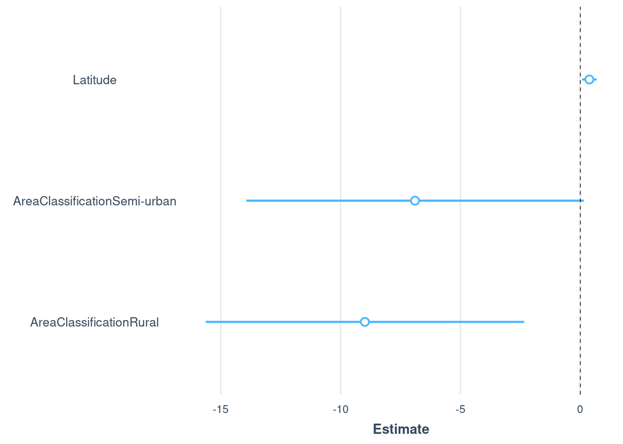

```r
plot_summs(lm8)
```

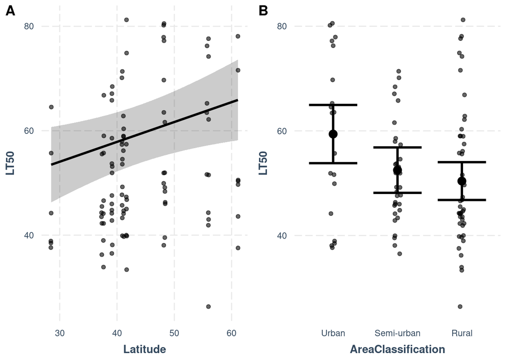

```r
a<-effect_plot(lm8, pred = Latitude, interval = TRUE, plot.points = TRUE,
            jitter = 0.05)

b<-effect_plot(lm8, pred = AreaClassification, interval = TRUE, plot.points = TRUE,
            jitter = 0.05)
plot_grid(a,b,nrow=1,labels=c("A", "B"))
```

```r
data$AreaClassification <- factor(data$AreaClassification, levels=c("Urban", "Semi-urban","Rural"))

data$map<-""
data[data$Strain=="ES_TEN" | data$Strain=="ES_COR" | data$Strain=="ES_GIM" | data$Strain=="ES_GUA" | data$Strain=="ES_TOM" | data$Strain=="IT_CAS" | data$Strain=="PT_REC",]$map<-"SE"
data[data$Strain=="AT_MUT" | data$Strain=="DE_MUN" | data$Strain=="DK_JUT" | data$Strain=="FI_AKA" | data$Strain=="SE_LUN" ,]$map<-"NE"
wilcox.test(data[data$map=="NE",]$LT50,data[data$map=="SE",]$LT50)
```

```
##
##  Wilcoxon rank sum test with continuity correction
##
## data:  data[data$map == "NE", ]$LT50 and data[data$map == "SE", ]$LT50
## W = 1362, p-value = 0.0378
## alternative hypothesis: true location shift is not equal to 0
```

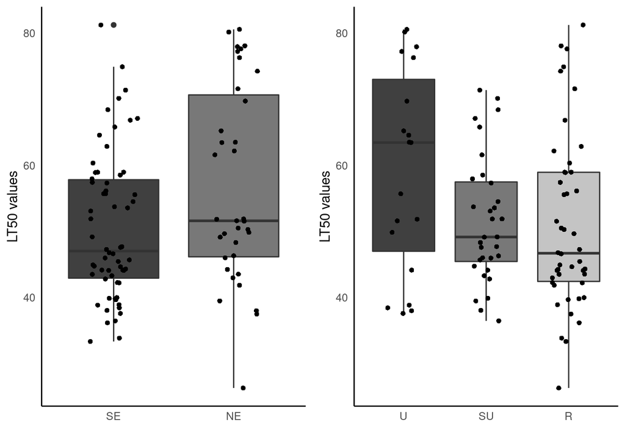

```r
data$map <- factor(data$map, levels=c("SE", "NE"))

d<-ggplot(data, aes(x=AreaClassification, y=LT50, fill=AreaClassification)) +
    geom_boxplot(show.legend = FALSE) + scale_fill_manual(values=c("gray25", "gray47", "gray77")) + geom_jitter(shape=16, position=position_jitter(0.2), show.legend = FALSE) + labs(x="", y = "LT50 values") + scale_x_discrete(breaks = c("Rural", "Semi-urban", "Urban"), labels = c("R", "SU", "U")) +
  theme(axis.ticks = element_blank()) + theme(panel.grid.major = element_blank(), panel.grid.minor = element_blank(),
panel.background = element_blank(), axis.line = element_line(colour = "black"))

c<-ggplot(data, aes(x=map, y=LT50, fill=map)) +
    geom_boxplot(show.legend = FALSE) + scale_fill_manual(values=c("gray25", "gray47")) + geom_jitter(shape=16, position=position_jitter(0.2), show.legend = FALSE) + labs(x="", y = "LT50 values") +
  theme(axis.ticks = element_blank()) + theme(panel.grid.major = element_blank(), panel.grid.minor = element_blank(),
panel.background = element_blank(), axis.line = element_line(colour = "black"))

plot_grid(c,d)
```

```r
 ggsave("Figure1CD.pdf", width = 7)
```

## Correlation variables

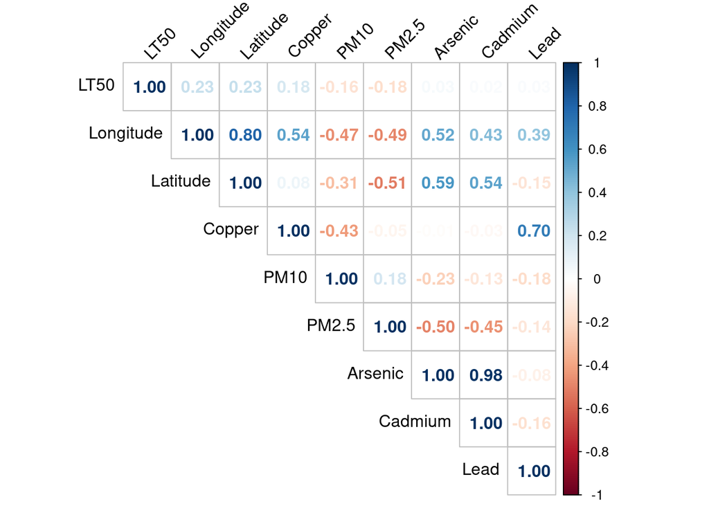

```r
corrplot(cor(unique(na.omit(data[,c("LT50","Longitude","Latitude","Copper","PM10","PM2.5","Arsenic","Cadmium","Lead")]))), method="number",  type="upper", tl.col="black",tl.srt=45)
```

## Same procedure starting with Arsenic and removing Cadmium

### Linear models

LM with all variables:

```r
lmAll = lm(LT50  ~ Longitude + Latitude +
           Copper + PM10 + PM2.5 +
           Arsenic + Lead +
           AreaClassification,
         data = data)
summary(lmAll)
```

```
##
## Call:
## lm(formula = LT50 ~ Longitude + Latitude + Copper + PM10 + PM2.5 +
##     Arsenic + Lead + AreaClassification, data = data)
##
## Residuals:
##     Min      1Q  Median      3Q     Max
## -27.570  -8.395  -1.899   8.811  29.446
##
## Coefficients:
##                               Estimate Std. Error t value Pr(>|t|)
## (Intercept)                  -58.24781   54.52490  -1.068  0.28865
## Longitude                     -1.79411    1.12106  -1.600  0.11351
## Latitude                       2.31083    1.14673   2.015  0.04729 *
## Copper                         0.76200    0.39607   1.924  0.05797 .
## PM10                          -0.18245    0.39621  -0.460  0.64643
## PM2.5                          0.75272    0.56771   1.326  0.18870
## Arsenic                        1.99950    1.67052   1.197  0.23491
## Lead                           1.37411    1.53863   0.893  0.37453
## AreaClassificationSemi-urban   0.01481    7.63920   0.002  0.99846
## AreaClassificationRural      -16.55002    6.13699  -2.697  0.00855 **
## ---
## Signif. codes:  0 '***' 0.001 '**' 0.01 '*' 0.05 '.' 0.1 ' ' 1
##
## Residual standard error: 12.46 on 79 degrees of freedom
##   (8 observations deleted due to missingness)
## Multiple R-squared:  0.1915, Adjusted R-squared:  0.09944
## F-statistic:  2.08 on 9 and 79 DF,  p-value: 0.04117
```

### Backward stepwise regression

```r
dropterm(lmAll, test = "F")
```

```
## Single term deletions
##
## Model:
## LT50 ~ Longitude + Latitude + Copper + PM10 + PM2.5 + Arsenic +
##     Lead + AreaClassification
##                    Df Sum of Sq   RSS    AIC F Value   Pr(F)
## <none>                          12267 458.42
## Longitude           1    397.71 12665 459.26  2.5612 0.11351
## Latitude            1    630.58 12898 460.88  4.0608 0.04729 *
## Copper              1    574.76 12842 460.49  3.7014 0.05797 .
## PM10                1     32.93 12300 456.66  0.2120 0.64643
## PM2.5               1    272.98 12540 458.38  1.7580 0.18870
## Arsenic             1    222.47 12490 458.02  1.4326 0.23491
## Lead                1    123.85 12391 457.31  0.7976 0.37453
## AreaClassification  2   1155.13 13422 462.43  3.7194 0.02859 *
## ---
## Signif. codes:  0 '***' 0.001 '**' 0.01 '*' 0.05 '.' 0.1 ' ' 1
```

We first remove `PM10`, as it is the least significant variable.

```r
lm2 = lm(LT50  ~ Longitude + Latitude +
           Copper + PM2.5 +
           Arsenic + Lead +
           AreaClassification,
         data = data)
summary(lm2)
```

```
##
## Call:
## lm(formula = LT50 ~ Longitude + Latitude + Copper + PM2.5 + Arsenic +
##     Lead + AreaClassification, data = data)
##
## Residuals:
##     Min      1Q  Median      3Q     Max
## -26.871  -8.498  -1.451   8.294  28.201
##
## Coefficients:
##                              Estimate Std. Error t value Pr(>|t|)
## (Intercept)                  -48.3188    49.8331  -0.970   0.3352
## Longitude                     -1.4909     0.9029  -1.651   0.1026
## Latitude                       2.0330     0.9703   2.095   0.0393 *
## Copper                         0.6843     0.3566   1.919   0.0585 .
## PM2.5                          0.7262     0.5620   1.292   0.2000
## Arsenic                        1.7827     1.5949   1.118   0.2670
## Lead                           1.2170     1.4929   0.815   0.4174
## AreaClassificationSemi-urban  -2.3445     5.6384  -0.416   0.6787
## AreaClassificationRural      -16.5564     6.1067  -2.711   0.0082 **
## ---
## Signif. codes:  0 '***' 0.001 '**' 0.01 '*' 0.05 '.' 0.1 ' ' 1
##
## Residual standard error: 12.4 on 80 degrees of freedom
##   (8 observations deleted due to missingness)
## Multiple R-squared:  0.1894, Adjusted R-squared:  0.1083
## F-statistic: 2.336 on 8 and 80 DF,  p-value: 0.02613
```

```r
dropterm(lm2, test = "F")
```

```
## Single term deletions
##
## Model:
## LT50 ~ Longitude + Latitude + Copper + PM2.5 + Arsenic + Lead +
##     AreaClassification
##                    Df Sum of Sq   RSS    AIC F Value   Pr(F)
## <none>                          12300 456.66
## Longitude           1    419.25 12720 457.64  2.7268 0.10260
## Latitude            1    674.93 12975 459.41  4.3897 0.03932 *
## Copper              1    566.26 12866 458.66  3.6829 0.05854 .
## PM2.5               1    256.73 12557 456.50  1.6698 0.20001
## Arsenic             1    192.10 12492 456.04  1.2494 0.26701
## Lead                1    102.17 12402 455.39  0.6645 0.41739
## AreaClassification  2   1132.58 13433 460.50  3.6831 0.02950 *
## ---
## Signif. codes:  0 '***' 0.001 '**' 0.01 '*' 0.05 '.' 0.1 ' ' 1
```

We remove `Lead`.

```r
lm3 =  lm(LT50  ~ Longitude + Latitude +
           Copper + PM2.5 +
           Arsenic +
           AreaClassification,
         data = data)
summary(lm3)
```

```
##
## Call:
## lm(formula = LT50 ~ Longitude + Latitude + Copper + PM2.5 + Arsenic +
##     AreaClassification, data = data)
##
## Residuals:
##     Min      1Q  Median      3Q     Max
## -27.725  -8.239  -2.979   8.521  28.106
##
## Coefficients:
##                              Estimate Std. Error t value Pr(>|t|)
## (Intercept)                  -23.4357    39.3083  -0.596  0.55270
## Longitude                     -1.0564     0.7272  -1.453  0.15018
## Latitude                       1.5194     0.7364   2.063  0.04230 *
## Copper                         0.6563     0.3542   1.853  0.06753 .
## PM2.5                          0.4645     0.4603   1.009  0.31593
## Arsenic                        1.1887     1.4157   0.840  0.40360
## AreaClassificationSemi-urban  -1.7078     5.5725  -0.306  0.76003
## AreaClassificationRural      -13.9411     5.1852  -2.689  0.00871 **
## ---
## Signif. codes:  0 '***' 0.001 '**' 0.01 '*' 0.05 '.' 0.1 ' ' 1
##
## Residual standard error: 12.37 on 81 degrees of freedom
##   (8 observations deleted due to missingness)
## Multiple R-squared:  0.1826, Adjusted R-squared:  0.112
## F-statistic: 2.586 on 7 and 81 DF,  p-value: 0.01855
```

```r
dropterm(lm3, test = "F")
```

```
## Single term deletions
##
## Model:
## LT50 ~ Longitude + Latitude + Copper + PM2.5 + Arsenic + AreaClassification
##                    Df Sum of Sq   RSS    AIC F Value   Pr(F)
## <none>                          12402 455.39
## Longitude           1    323.10 12726 455.68  2.1102 0.15018
## Latitude            1    651.77 13054 457.95  4.2567 0.04230 *
## Copper              1    525.70 12928 457.09  3.4334 0.06753 .
## PM2.5               1    155.92 12558 454.51  1.0183 0.31593
## Arsenic             1    107.94 12510 454.17  0.7049 0.40360
## AreaClassification  2   1108.24 13511 459.01  3.6190 0.03123 *
## ---
## Signif. codes:  0 '***' 0.001 '**' 0.01 '*' 0.05 '.' 0.1 ' ' 1
```

We remove `Arsenic`.

```r
lm4 = lm(LT50  ~ Longitude + Latitude +
           Copper + PM2.5 +
           AreaClassification,
         data = data)
summary(lm4)
```

```
##
## Call:
## lm(formula = LT50 ~ Longitude + Latitude + Copper + PM2.5 + AreaClassification,
##     data = data)
##
## Residuals:
##     Min      1Q  Median      3Q     Max
## -27.750  -8.723  -2.064   8.158  29.124
##
## Coefficients:
##                              Estimate Std. Error t value Pr(>|t|)
## (Intercept)                   -1.8611    26.2121  -0.071  0.94356
## Longitude                     -0.6413     0.3865  -1.659  0.10051
## Latitude                       1.1514     0.4978   2.313  0.02299 *
## Copper                         0.4624     0.2008   2.303  0.02356 *
## PM2.5                          0.2640     0.3149   0.839  0.40392
## AreaClassificationSemi-urban  -3.4995     4.2010  -0.833  0.40704
## AreaClassificationRural      -11.4579     3.7623  -3.045  0.00305 **
## ---
## Signif. codes:  0 '***' 0.001 '**' 0.01 '*' 0.05 '.' 0.1 ' ' 1
##
## Residual standard error: 12.05 on 90 degrees of freedom
## Multiple R-squared:  0.1693, Adjusted R-squared:  0.1139
## F-statistic: 3.057 on 6 and 90 DF,  p-value: 0.009084
```

```r
dropterm(lm4, test = "F")
```

```
## Single term deletions
##
## Model:
## LT50 ~ Longitude + Latitude + Copper + PM2.5 + AreaClassification
##                    Df Sum of Sq   RSS    AIC F Value   Pr(F)
## <none>                          13068 489.61
## Longitude           1    399.85 13468 490.54  2.7538 0.10051
## Latitude            1    776.94 13845 493.21  5.3507 0.02299 *
## Copper              1    770.44 13839 493.17  5.3060 0.02356 *
## PM2.5               1    102.11 13170 488.37  0.7032 0.40392
## AreaClassification  2   1350.44 14419 495.15  4.6502 0.01197 *
## ---
## Signif. codes:  0 '***' 0.001 '**' 0.01 '*' 0.05 '.' 0.1 ' ' 1
```

We remove `PM2.5`.

```r
lm5 =  lm(LT50  ~ Longitude + Latitude +
           Copper +
           AreaClassification,
         data = data)
summary(lm5)
```

```
##
## Call:
## lm(formula = LT50 ~ Longitude + Latitude + Copper + AreaClassification,
##     data = data)
##
## Residuals:
##     Min      1Q  Median      3Q     Max
## -27.665  -9.797  -2.538   8.165  30.067
##
## Coefficients:
##                              Estimate Std. Error t value Pr(>|t|)
## (Intercept)                   11.8756    20.4300   0.581  0.56249
## Longitude                     -0.5083     0.3518  -1.445  0.15198
## Latitude                       0.9288     0.4204   2.209  0.02965 *
## Copper                         0.3998     0.1860   2.149  0.03429 *
## AreaClassificationSemi-urban  -3.7519     4.1833  -0.897  0.37215
## AreaClassificationRural      -10.1280     3.4061  -2.973  0.00377 **
## ---
## Signif. codes:  0 '***' 0.001 '**' 0.01 '*' 0.05 '.' 0.1 ' ' 1
##
## Residual standard error: 12.03 on 91 degrees of freedom
## Multiple R-squared:  0.1628, Adjusted R-squared:  0.1168
## F-statistic: 3.539 on 5 and 91 DF,  p-value: 0.005717
```

```r
dropterm(lm5, test = "F")
```

```
## Single term deletions
##
## Model:
## LT50 ~ Longitude + Latitude + Copper + AreaClassification
##                    Df Sum of Sq   RSS    AIC F Value   Pr(F)
## <none>                          13170 488.37
## Longitude           1    302.06 13472 488.57  2.0871 0.15198
## Latitude            1    706.52 13877 491.44  4.8817 0.02965 *
## Copper              1    668.38 13839 491.17  4.6182 0.03429 *
## AreaClassification  2   1291.59 14462 493.44  4.4621 0.01417 *
## ---
## Signif. codes:  0 '***' 0.001 '**' 0.01 '*' 0.05 '.' 0.1 ' ' 1
```

We remove `Longitude`.

```r
lm6 = lm(LT50  ~ Latitude +
           Copper +
           AreaClassification,
         data = data)
summary(lm6)
```

```
##
## Call:
## lm(formula = LT50 ~ Latitude + Copper + AreaClassification, data = data)
##
## Residuals:
##     Min      1Q  Median      3Q     Max
## -27.025  -9.115  -3.353   8.646  30.439
##
## Coefficients:
##                              Estimate Std. Error t value Pr(>|t|)
## (Intercept)                   39.3692     7.4738   5.268 9.04e-07 ***
## Latitude                       0.3625     0.1528   2.372  0.01976 *
## Copper                         0.1912     0.1180   1.620  0.10860
## AreaClassificationSemi-urban  -7.0701     3.5170  -2.010  0.04733 *
## AreaClassificationRural       -8.8992     3.3177  -2.682  0.00867 **
## ---
## Signif. codes:  0 '***' 0.001 '**' 0.01 '*' 0.05 '.' 0.1 ' ' 1
##
## Residual standard error: 12.1 on 92 degrees of freedom
## Multiple R-squared:  0.1436, Adjusted R-squared:  0.1064
## F-statistic: 3.856 on 4 and 92 DF,  p-value: 0.006087
```

```r
dropterm(lm6, test = "F")
```

```
## Single term deletions
##
## Model:
## LT50 ~ Latitude + Copper + AreaClassification
##                    Df Sum of Sq   RSS    AIC F Value   Pr(F)
## <none>                          13472 488.57
## Latitude            1    824.20 14297 492.33  5.6283 0.01976 *
## Copper              1    384.44 13857 489.30  2.6252 0.10860
## AreaClassification  2   1070.99 14543 491.99  3.6568 0.02964 *
## ---
## Signif. codes:  0 '***' 0.001 '**' 0.01 '*' 0.05 '.' 0.1 ' ' 1
```

We remove `Copper`.

```r
lm7 = lm(LT50  ~ Latitude +
           AreaClassification,
         data = data)
summary(lm7)
```

```
##
## Call:
## lm(formula = LT50 ~ Latitude + AreaClassification, data = data)
##
## Residuals:
##     Min      1Q  Median      3Q     Max
## -28.585  -9.038  -3.019   7.931  31.731
##
## Coefficients:
##                              Estimate Std. Error t value Pr(>|t|)
## (Intercept)                   42.6495     7.2570   5.877 6.47e-08 ***
## Latitude                       0.3804     0.1537   2.474  0.01517 *
## AreaClassificationSemi-urban  -6.8944     3.5459  -1.944  0.05488 .
## AreaClassificationRural       -8.9863     3.3461  -2.686  0.00857 **
## ---
## Signif. codes:  0 '***' 0.001 '**' 0.01 '*' 0.05 '.' 0.1 ' ' 1
##
## Residual standard error: 12.21 on 93 degrees of freedom
## Multiple R-squared:  0.1192, Adjusted R-squared:  0.09074
## F-statistic: 4.193 on 3 and 93 DF,  p-value: 0.007872
```

```r
Anova(lm7)
```

```
## Anova Table (Type II tests)
##
## Response: LT50
##                     Sum Sq Df F value  Pr(>F)
## Latitude             912.0  1  6.1210 0.01517 *
## AreaClassification  1084.1  2  3.6378 0.03012 *
## Residuals          13856.8 93
## ---
## Signif. codes:  0 '***' 0.001 '**' 0.01 '*' 0.05 '.' 0.1 ' ' 1
```

```r
dropterm(lm7, test = "F")
```

```
## Single term deletions
##
## Model:
## LT50 ~ Latitude + AreaClassification
##                    Df Sum of Sq   RSS    AIC F Value   Pr(F)
## <none>                          13857 489.30
## Latitude            1    912.01 14769 493.48  6.1210 0.01517 *
## AreaClassification  2   1084.06 14941 492.60  3.6378 0.03012 *
## ---
## Signif. codes:  0 '***' 0.001 '**' 0.01 '*' 0.05 '.' 0.1 ' ' 1
```

Because now all terms are significant, it means that the relevant variables to explain LT50 are `Latitude` and `AreaClassification`.

We explain 12% of the variance, and the p-value is 0.008. The most important variable is `Urban category - Urban`.

## Same procedure starting with Cadmium and removing Arsenic

### Linear models

LM with all variables:

```r
lmAll = lm(LT50  ~ Longitude + Latitude +
           Copper + PM10 + PM2.5 +
           Cadmium + Lead +
           AreaClassification,
         data = data)
summary(lmAll)
```

```
##
## Call:
## lm(formula = LT50 ~ Longitude + Latitude + Copper + PM10 + PM2.5 +
##     Cadmium + Lead + AreaClassification, data = data)
##
## Residuals:
##     Min      1Q  Median      3Q     Max
## -27.612  -8.339  -1.914   8.695  29.439
##
## Coefficients:
##                              Estimate Std. Error t value Pr(>|t|)
## (Intercept)                  -63.1410    58.0980  -1.087  0.28043
## Longitude                     -1.9302     1.2156  -1.588  0.11631
## Latitude                       2.4728     1.2540   1.972  0.05212 .
## Copper                         0.7582     0.3964   1.913  0.05938 .
## PM10                          -0.3179     0.4434  -0.717  0.47557
## PM2.5                          0.7687     0.5809   1.323  0.18960
## Cadmium                       12.9248    10.9588   1.179  0.24178
## Lead                           1.6604     1.6780   0.990  0.32544
## AreaClassificationSemi-urban   1.5853     8.2125   0.193  0.84743
## AreaClassificationRural      -16.3870     6.0865  -2.692  0.00866 **
## ---
## Signif. codes:  0 '***' 0.001 '**' 0.01 '*' 0.05 '.' 0.1 ' ' 1
##
## Residual standard error: 12.46 on 79 degrees of freedom
##   (8 observations deleted due to missingness)
## Multiple R-squared:  0.1911, Adjusted R-squared:  0.09897
## F-statistic: 2.074 on 9 and 79 DF,  p-value: 0.04174
```

### Backward stepwise regression

```r
dropterm(lmAll, test = "F")
```

```
## Single term deletions
##
## Model:
## LT50 ~ Longitude + Latitude + Copper + PM10 + PM2.5 + Cadmium +
##     Lead + AreaClassification
##                    Df Sum of Sq   RSS    AIC F Value   Pr(F)
## <none>                          12274 458.47
## Longitude           1    391.72 12665 459.26  2.5213 0.11631
## Latitude            1    604.14 12878 460.74  3.8885 0.05212 .
## Copper              1    568.53 12842 460.50  3.6594 0.05938 .
## PM10                1     79.84 12354 457.04  0.5139 0.47557
## PM2.5               1    272.01 12546 458.42  1.7508 0.18960
## Cadmium             1    216.11 12490 458.02  1.3910 0.24178
## Lead                1    152.12 12426 457.56  0.9791 0.32544
## AreaClassification  2   1138.65 13412 462.36  3.6645 0.03007 *
## ---
## Signif. codes:  0 '***' 0.001 '**' 0.01 '*' 0.05 '.' 0.1 ' ' 1
```

We first remove `PM10`, as it is the least significant variable.

```r
lm2 = lm(LT50  ~ Longitude + Latitude +
           Copper + PM2.5 +
           Cadmium + Lead +
           AreaClassification,
         data = data)
summary(lm2)
```

```
##
## Call:
## lm(formula = LT50 ~ Longitude + Latitude + Copper + PM2.5 + Cadmium +
##     Lead + AreaClassification, data = data)
##
## Residuals:
##     Min      1Q  Median      3Q     Max
## -26.733  -8.595  -1.533   8.165  27.719
##
## Coefficients:
##                              Estimate Std. Error t value Pr(>|t|)
## (Intercept)                  -40.0491    48.2033  -0.831   0.4085
## Longitude                     -1.3103     0.8517  -1.538   0.1279
## Latitude                       1.8828     0.9432   1.996   0.0493 *
## Copper                         0.6047     0.3325   1.819   0.0727 .
## PM2.5                          0.6526     0.5562   1.173   0.2442
## Cadmium                        8.8829     9.3685   0.948   0.3459
## Lead                           1.2062     1.5490   0.779   0.4385
## AreaClassificationSemi-urban  -2.6968     5.6189  -0.480   0.6326
## AreaClassificationRural      -15.6522     5.9813  -2.617   0.0106 *
## ---
## Signif. codes:  0 '***' 0.001 '**' 0.01 '*' 0.05 '.' 0.1 ' ' 1
##
## Residual standard error: 12.43 on 80 degrees of freedom
##   (8 observations deleted due to missingness)
## Multiple R-squared:  0.1859, Adjusted R-squared:  0.1044
## F-statistic: 2.283 on 8 and 80 DF,  p-value: 0.02959
```

```r
dropterm(lm2, test = "F")
```

```
## Single term deletions
##
## Model:
## LT50 ~ Longitude + Latitude + Copper + PM2.5 + Cadmium + Lead +
##     AreaClassification
##                    Df Sum of Sq   RSS    AIC F Value   Pr(F)
## <none>                          12354 457.04
## Longitude           1    365.47 12719 457.64  2.3668 0.12789
## Latitude            1    615.30 12969 459.37  3.9846 0.04932 *
## Copper              1    510.70 12864 458.65  3.3072 0.07272 .
## PM2.5               1    212.57 12566 456.56  1.3766 0.24416
## Cadmium             1    138.82 12492 456.04  0.8990 0.34590
## Lead                1     93.62 12447 455.71  0.6063 0.43849
## AreaClassification  2   1059.92 13414 460.37  3.4320 0.03716 *
## ---
## Signif. codes:  0 '***' 0.001 '**' 0.01 '*' 0.05 '.' 0.1 ' ' 1
```

We remove `Lead`.

```r
lm3 = lm(LT50  ~ Longitude + Latitude +
           Copper + PM2.5 +
           Cadmium  +
           AreaClassification,
         data = data)
summary(lm3)
```

```
##
## Call:
## lm(formula = LT50 ~ Longitude + Latitude + Copper + PM2.5 + Cadmium +
##     AreaClassification, data = data)
##
## Residuals:
##     Min      1Q  Median      3Q     Max
## -27.403  -8.340  -2.783   8.807  27.940
##
## Coefficients:
##                              Estimate Std. Error t value Pr(>|t|)
## (Intercept)                  -16.1108    37.0363  -0.435   0.6647
## Longitude                     -0.9042     0.6717  -1.346   0.1820
## Latitude                       1.3907     0.6985   1.991   0.0498 *
## Copper                         0.5871     0.3309   1.774   0.0798 .
## PM2.5                          0.3939     0.4450   0.885   0.3787
## Cadmium                        5.1497     8.0291   0.641   0.5231
## AreaClassificationSemi-urban  -2.1132     5.5552  -0.380   0.7046
## AreaClassificationRural      -13.0803     4.9744  -2.629   0.0102 *
## ---
## Signif. codes:  0 '***' 0.001 '**' 0.01 '*' 0.05 '.' 0.1 ' ' 1
##
## Residual standard error: 12.4 on 81 degrees of freedom
##   (8 observations deleted due to missingness)
## Multiple R-squared:  0.1797, Adjusted R-squared:  0.1088
## F-statistic: 2.535 on 7 and 81 DF,  p-value: 0.02072
```

```r
dropterm(lm3, test = "F")
```

```
## Single term deletions
##
## Model:
## LT50 ~ Longitude + Latitude + Copper + PM2.5 + Cadmium + AreaClassification
##                    Df Sum of Sq   RSS    AIC F Value   Pr(F)
## <none>                          12447 455.71
## Longitude           1    278.44 12726 455.68  1.8120 0.18203
## Latitude            1    609.18 13056 457.97  3.9642 0.04985 *
## Copper              1    483.69 12931 457.11  3.1476 0.07980 .
## PM2.5               1    120.40 12568 454.57  0.7835 0.37869
## Cadmium             1     63.21 12510 454.17  0.4114 0.52309
## AreaClassification  2   1064.75 13512 459.02  3.4644 0.03600 *
## ---
## Signif. codes:  0 '***' 0.001 '**' 0.01 '*' 0.05 '.' 0.1 ' ' 1
```

We remove `Cadmium`.

```r
lm4 = lm(LT50  ~ Longitude + Latitude +
           Copper + PM2.5 +
           AreaClassification,
         data = data)
summary(lm4)
```

```
##
## Call:
## lm(formula = LT50 ~ Longitude + Latitude + Copper + PM2.5 + AreaClassification,
##     data = data)
##
## Residuals:
##     Min      1Q  Median      3Q     Max
## -27.750  -8.723  -2.064   8.158  29.124
##
## Coefficients:
##                              Estimate Std. Error t value Pr(>|t|)
## (Intercept)                   -1.8611    26.2121  -0.071  0.94356
## Longitude                     -0.6413     0.3865  -1.659  0.10051
## Latitude                       1.1514     0.4978   2.313  0.02299 *
## Copper                         0.4624     0.2008   2.303  0.02356 *
## PM2.5                          0.2640     0.3149   0.839  0.40392
## AreaClassificationSemi-urban  -3.4995     4.2010  -0.833  0.40704
## AreaClassificationRural      -11.4579     3.7623  -3.045  0.00305 **
## ---
## Signif. codes:  0 '***' 0.001 '**' 0.01 '*' 0.05 '.' 0.1 ' ' 1
##
## Residual standard error: 12.05 on 90 degrees of freedom
## Multiple R-squared:  0.1693, Adjusted R-squared:  0.1139
## F-statistic: 3.057 on 6 and 90 DF,  p-value: 0.009084
```

```r
dropterm(lm4, test = "F")
```

```
## Single term deletions
##
## Model:
## LT50 ~ Longitude + Latitude + Copper + PM2.5 + AreaClassification
##                    Df Sum of Sq   RSS    AIC F Value   Pr(F)
## <none>                          13068 489.61
## Longitude           1    399.85 13468 490.54  2.7538 0.10051
## Latitude            1    776.94 13845 493.21  5.3507 0.02299 *
## Copper              1    770.44 13839 493.17  5.3060 0.02356 *
## PM2.5               1    102.11 13170 488.37  0.7032 0.40392
## AreaClassification  2   1350.44 14419 495.15  4.6502 0.01197 *
## ---
## Signif. codes:  0 '***' 0.001 '**' 0.01 '*' 0.05 '.' 0.1 ' ' 1
```

We remove `PM2.5`.

```r
lm5 = lm(LT50  ~ Longitude + Latitude +
           Copper +
           AreaClassification,
         data = data)
summary(lm5)
```

```
##
## Call:
## lm(formula = LT50 ~ Longitude + Latitude + Copper + AreaClassification,
##     data = data)
##
## Residuals:
##     Min      1Q  Median      3Q     Max
## -27.665  -9.797  -2.538   8.165  30.067
##
## Coefficients:
##                              Estimate Std. Error t value Pr(>|t|)
## (Intercept)                   11.8756    20.4300   0.581  0.56249
## Longitude                     -0.5083     0.3518  -1.445  0.15198
## Latitude                       0.9288     0.4204   2.209  0.02965 *
## Copper                         0.3998     0.1860   2.149  0.03429 *
## AreaClassificationSemi-urban  -3.7519     4.1833  -0.897  0.37215
## AreaClassificationRural      -10.1280     3.4061  -2.973  0.00377 **
## ---
## Signif. codes:  0 '***' 0.001 '**' 0.01 '*' 0.05 '.' 0.1 ' ' 1
##
## Residual standard error: 12.03 on 91 degrees of freedom
## Multiple R-squared:  0.1628, Adjusted R-squared:  0.1168
## F-statistic: 3.539 on 5 and 91 DF,  p-value: 0.005717
```

```r
dropterm(lm5, test = "F")
```

```
## Single term deletions
##
## Model:
## LT50 ~ Longitude + Latitude + Copper + AreaClassification
##                    Df Sum of Sq   RSS    AIC F Value   Pr(F)
## <none>                          13170 488.37
## Longitude           1    302.06 13472 488.57  2.0871 0.15198
## Latitude            1    706.52 13877 491.44  4.8817 0.02965 *
## Copper              1    668.38 13839 491.17  4.6182 0.03429 *
## AreaClassification  2   1291.59 14462 493.44  4.4621 0.01417 *
## ---
## Signif. codes:  0 '***' 0.001 '**' 0.01 '*' 0.05 '.' 0.1 ' ' 1
```

We remove `Longitude`.

```r
lm6 = lm(LT50  ~  Latitude +
           Copper +
           AreaClassification,
         data = data)
summary(lm6)
```

```
##
## Call:
## lm(formula = LT50 ~ Latitude + Copper + AreaClassification, data = data)
##
## Residuals:
##     Min      1Q  Median      3Q     Max
## -27.025  -9.115  -3.353   8.646  30.439
##
## Coefficients:
##                              Estimate Std. Error t value Pr(>|t|)
## (Intercept)                   39.3692     7.4738   5.268 9.04e-07 ***
## Latitude                       0.3625     0.1528   2.372  0.01976 *
## Copper                         0.1912     0.1180   1.620  0.10860
## AreaClassificationSemi-urban  -7.0701     3.5170  -2.010  0.04733 *
## AreaClassificationRural       -8.8992     3.3177  -2.682  0.00867 **
## ---
## Signif. codes:  0 '***' 0.001 '**' 0.01 '*' 0.05 '.' 0.1 ' ' 1
##
## Residual standard error: 12.1 on 92 degrees of freedom
## Multiple R-squared:  0.1436, Adjusted R-squared:  0.1064
## F-statistic: 3.856 on 4 and 92 DF,  p-value: 0.006087
```

```r
dropterm(lm6, test = "F")
```

```
## Single term deletions
##
## Model:
## LT50 ~ Latitude + Copper + AreaClassification
##                    Df Sum of Sq   RSS    AIC F Value   Pr(F)
## <none>                          13472 488.57
## Latitude            1    824.20 14297 492.33  5.6283 0.01976 *
## Copper              1    384.44 13857 489.30  2.6252 0.10860
## AreaClassification  2   1070.99 14543 491.99  3.6568 0.02964 *
## ---
## Signif. codes:  0 '***' 0.001 '**' 0.01 '*' 0.05 '.' 0.1 ' ' 1
```

We remove `Copper`.

```r
lm7 = lm(LT50  ~  Latitude +
           AreaClassification,
         data = data)
summary(lm7)
```

```
##
## Call:
## lm(formula = LT50 ~ Latitude + AreaClassification, data = data)
##
## Residuals:
##     Min      1Q  Median      3Q     Max
## -28.585  -9.038  -3.019   7.931  31.731
##
## Coefficients:
##                              Estimate Std. Error t value Pr(>|t|)
## (Intercept)                   42.6495     7.2570   5.877 6.47e-08 ***
## Latitude                       0.3804     0.1537   2.474  0.01517 *
## AreaClassificationSemi-urban  -6.8944     3.5459  -1.944  0.05488 .
## AreaClassificationRural       -8.9863     3.3461  -2.686  0.00857 **
## ---
## Signif. codes:  0 '***' 0.001 '**' 0.01 '*' 0.05 '.' 0.1 ' ' 1
##
## Residual standard error: 12.21 on 93 degrees of freedom
## Multiple R-squared:  0.1192, Adjusted R-squared:  0.09074
## F-statistic: 4.193 on 3 and 93 DF,  p-value: 0.007872
```

```r
Anova(lm7)
```

```
## Anova Table (Type II tests)
##
## Response: LT50
##                     Sum Sq Df F value  Pr(>F)
## Latitude             912.0  1  6.1210 0.01517 *
## AreaClassification  1084.1  2  3.6378 0.03012 *
## Residuals          13856.8 93
## ---
## Signif. codes:  0 '***' 0.001 '**' 0.01 '*' 0.05 '.' 0.1 ' ' 1
```

```r
dropterm(lm7, test = "F")
```

```
## Single term deletions
##
## Model:
## LT50 ~ Latitude + AreaClassification
##                    Df Sum of Sq   RSS    AIC F Value   Pr(F)
## <none>                          13857 489.30
## Latitude            1    912.01 14769 493.48  6.1210 0.01517 *
## AreaClassification  2   1084.06 14941 492.60  3.6378 0.03012 *
## ---
## Signif. codes:  0 '***' 0.001 '**' 0.01 '*' 0.05 '.' 0.1 ' ' 1
```

Because now all terms are significant, it means that the relevant variables to explain LT50 are `Latitude` and `AreaClassification`.

We explain 12% of the variance, and the p-value is 0.008. The most important variable is `Urban category - Urban`.